# Coursera Practical Machine Learning Project Report

Morteza Taiebat

# Background

Using devices such as Jawbone Up, Nike FuelBand, and Fitbit it is now possible to collect a large amount of data about personal activity relatively inexpensively. These type of devices are part of the quantified self movement – a group of enthusiasts who take measurements about themselves regularly to improve their health, to find patterns in their behavior, or because they are tech geeks. One thing that people regularly do is quantify how much of a particular activity they do, but they rarely quantify how well they do it.

# Problem Statement

In this project, we will use data from accelerometers on the belt, forearm, arm, and dumbell of 6 participants to *predict* the manner in which they performed the exercise.

## Data Source

The data for this exerise is supplied via the following link: http://groupware.les.inf.puc-rio.br/har

# Initialization

Load all required pacakges.

```r
lapply(list('caret', 'rpart', 'rpart.plot', 'corrplot'), require, character.only = TRUE)
```

```
## [[1]]
## [1] TRUE
##
## [[2]]
## [1] TRUE
##
## [[3]]
## [1] TRUE
##
## [[4]]
## [1] TRUE
```

## Load the Data

```r
train <- read.csv("./data/pml-training.csv")
test <- read.csv("./data/pml-testing.csv")
```

The training data set contains 19622 observations and 160 variables, while the testing data set contains 20 observations and 160 variables.

The variable “classe” in the training set is the outcome to predict.

## Data Cleaning

In this step, we will clean the data and remove observations with missing values as well as some meaningless variables.

```r
train <- train[, colSums(is.na(train)) == 0]
classe <- train$classe
trainRemove <- grepl("^X|timestamp|window", names(train))
train <- train[, !trainRemove]
trainCleaned <- train[, sapply(train, is.numeric)]
trainCleaned$classe <- classe
testRemove <- grepl("^X|timestamp|window", names(test))
test <- test[, !testRemove]
testCleaned <- test[, sapply(test, is.numeric)]
```

Now, the cleaned training data set contains 19622 observations and 53 variables, while the testing data set contains 20 observations and 53 variables. The “classe” variable is still in the cleaned training set.

## Data Splitting

Then, we can split the cleaned training set into a pure training data set (70%) and a validation data set (30%). We will use the validation data set to conduct cross validation in future steps.

```r
set.seed(22519)
inTrain <- createDataPartition(trainCleaned$classe, p=0.70, list=F)
trainData <- trainCleaned[inTrain, ]
testData <- trainCleaned[-inTrain, ]
```

## Visualization of Correlation Matrix

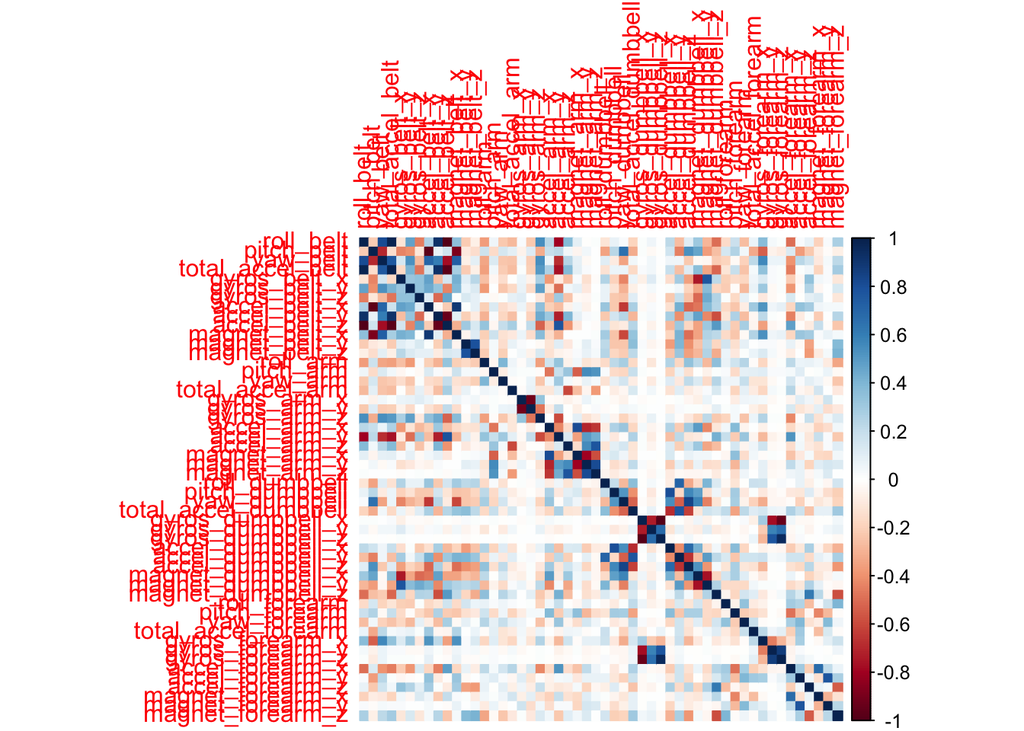

```r
corrPlot <- cor(trainData[, -length(names(trainData))])
corrplot(corrPlot, method="color")
```